# ggplot Cheatsheet - basics

[GGPLOT2 - Elegant Graphics for Data Analysis](https://ggplot2-book.org/index.html) by Hadley Wickham, Danielle Navarro, and Thomas Lin Pedersen

# Intro

This is my personal cheatsheet for when I need to recall basic ggplot commands and features.

```
# To list datasets in ggplot:
data(package="ggplot2")$results[ , "Item"]

# To list the data sets in all available packages
data(package=.packages(all.available=TRUE))
```

# 1 THEME

My favorite custom theme:

```r
theme_set(theme_light(base_size=9))
theme_update(
  panel.grid.minor = element_blank(),
  panel.grid.major = element_line(colour="gray90", linewidth=0.2),
  plot.title    = element_text(size=10, colour="gray30", face="bold"),
  plot.subtitle = element_text(size= 9, colour="gray50", face='italic'),
  plot.caption  = element_text(size= 7, colour="gray50", hjust=0),
  legend.title = element_blank(),
  legend.position = "top"
)
```

To edit a specific setting or option within a ggplot

```
theme(
  line=element_line(colour='gray70'),
  rect=element_rect(colour='gray70'),
  text=element_text(colour='gray70'),
  panel.border=element_rect(fill=NA, color="gray90"),
  axis.title=element_text(),
  axis.ticks=element_blank(),
  axis.text=element_text(colour="gray50", size=9),
  legend.position="top",
  legend.text=element_text(color="Gray50", size=8),
  plot.margin=margin(rep(10, 4)) # add some white space around the plot
)
```

To list each of the specific settings or options, just call the theme:

```
theme_classic()
```

You can also list settings of a specific element of the plot theme.

```r
theme_classic()$panel.grid
```

```
## List of 6
##  $ colour       : chr "grey92"
##  $ linewidth    : NULL
##  $ linetype     : NULL
##  $ lineend      : NULL
##  $ arrow        : logi FALSE
##  $ inherit.blank: logi TRUE
##  - attr(*, "class")= chr [1:2] "element_line" "element"
```

# 2 COLORS

[Slide presentation on using colors](https://www.reisanar.com/slides/colors#1)

[Comprehensive list of default palettes available in R](https://github.com/EmilHvitfeldt/r-color-palettes)

You can modify the default ggplot colors by using predefined color palettes available in different R packages. The most commonly used color scales, include:

- Viridis color scales [viridis package].
- Colorbrewer palettes [RColorBrewer package]
- Grey color palettes [ggplot2 package]
- Scientific journal color palettes [ggsci package]
- Wes Anderson color palettes [wesanderson package]

Learn more at: [Top R Color Palettes to Know for Great Data Visualization](https://www.datanovia.com/en/blog/top-r-color-palettes-to-know-for-great-data-visualization/)

## 2.1 ggplot default

**Specify a single color**

- [Awesome List Of 657 R Color Names](https://www.datanovia.com/en/blog/awesome-list-of-657-r-color-names/)
- [Awesome List of Hexadecimal Colors You Should Have](https://www.datanovia.com/en/blog/awesome-list-of-hexadecimal-colors-you-should-have/)

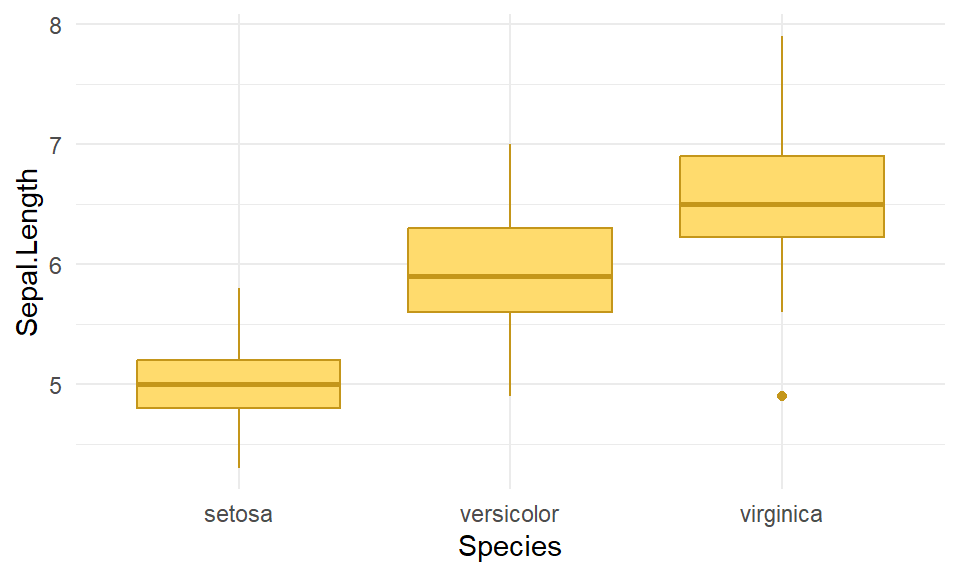

```r
# Box plot
ggplot(iris, aes(Species, Sepal.Length)) +
  geom_boxplot(fill="#FFDB6D", color="#C4961A") +
  theme_minimal()
```

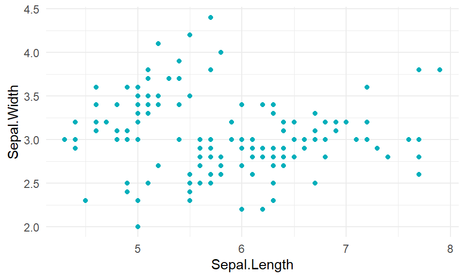

```r
# Scatter plot
ggplot(iris, aes(Sepal.Length, Sepal.Width)) +
  geom_point(color="#00AFBB") +
  theme_minimal()
```

**Color by group/category**

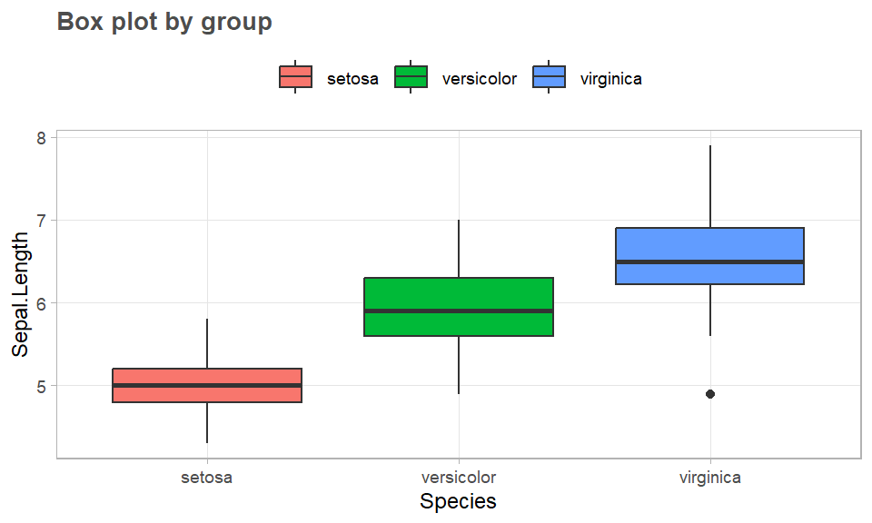

```r
ggplot(iris, aes(Species, Sepal.Length)) +
  geom_boxplot(aes(fill=Species)) +
  theme(legend.position="top") +
  labs(title="Box plot by group")
```

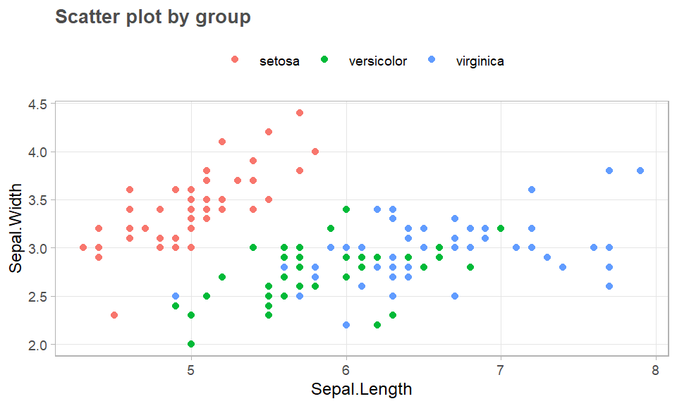

```r
ggplot(iris, aes(Sepal.Length, Sepal.Width)) +
  geom_point(aes(color=Species)) +
  theme(legend.position="top") +
  labs(title="Scatter plot by group")
```

**Get the HEX code**

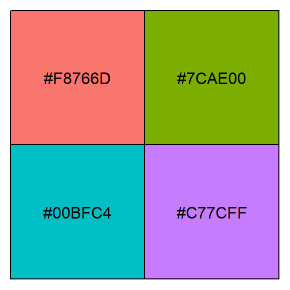

```r
scales::show_col(scales::hue_pal()(4))
```

**Gradient colors**

[ggplot scale_gradient()](https://ggplot2.tidyverse.org/reference/scale_gradient.html#details):

For gradient colors, you map the argument `color` and/or `fill` to a continuous variable.

- `scale_color_gradient()`, `scale_fill_gradient()` for sequential gradients between two colors
- `scale_color_gradient2()`, `scale_fill_gradient2()` for diverging gradients
- `scale_color_gradientn()`, `scale_fill_gradientn()` for gradient between n colors

Set gradient between 2 colors and change the colors for low and high ends of the gradient:

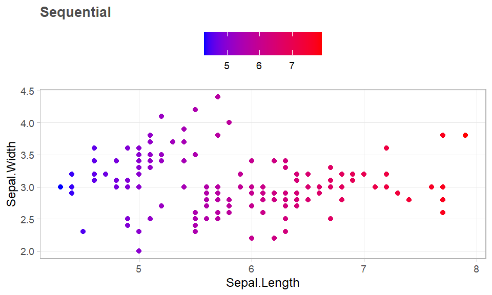

```r
# Specify the colors for low and high ends of gradient
ggplot(iris, aes(Sepal.Length, Sepal.Width)) +
  geom_point(aes(color=Sepal.Length)) +
  scale_color_gradient(low="blue", high="red") +
  labs(title="Sequential")
```

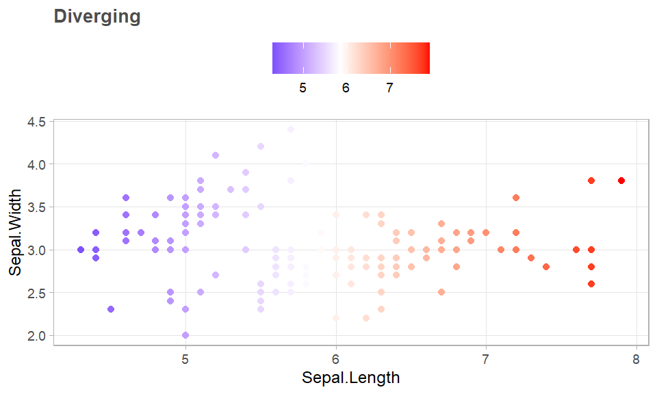

```r
# Specify also the colour for mid point
ggplot(iris, aes(Sepal.Length, Sepal.Width)) +
  geom_point(aes(color=Sepal.Length)) +
  scale_color_gradient2(midpoint=mean(iris$Sepal.Length), low="blue", mid="white",
                        high="red", space="Lab" ) +
  labs(title="Diverging")
```

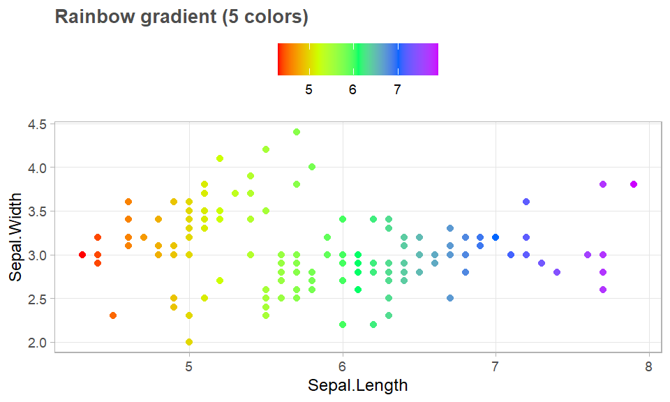

```r
ggplot(iris, aes(Sepal.Length, Sepal.Width)) +
  geom_point(aes(color=Sepal.Length)) +
  scale_color_gradientn(colours=rainbow(5)) +
  labs(title="Rainbow gradient (5 colors)")
```

Set ggplot color manually:

- `scale_fill_manual()` for box plot, bar plot, violin plot, dot plot, etc
- `scale_color_manual()` for lines and points

Use grey color scales:

- `scale_fill_grey()` for box plot, bar plot, violin plot, dot plot, etc
- `scale_colour_grey()` for points, lines, etc

## 2.2 ColorBrewer

Best all around. Easy **discrete** palettes for **colorblindness**

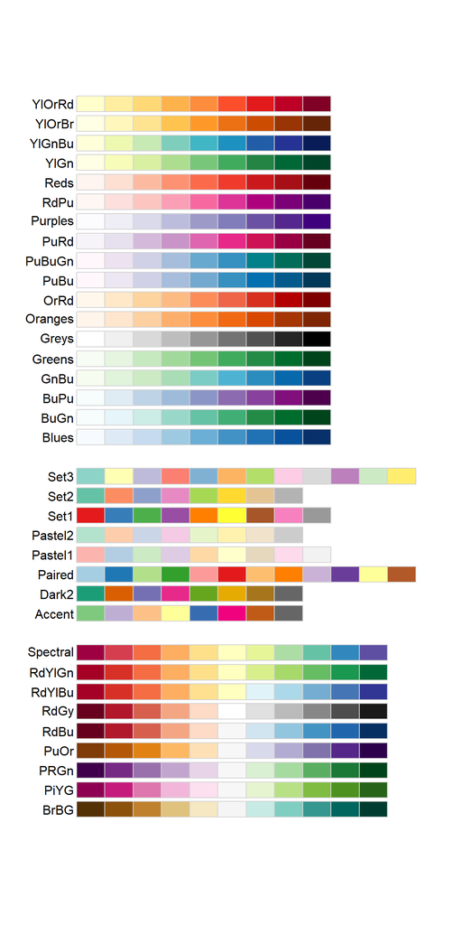

```r
library(RColorBrewer)
display.brewer.all() # to check all colorbrewer palettes
```

**Palettes for colorblindness:**

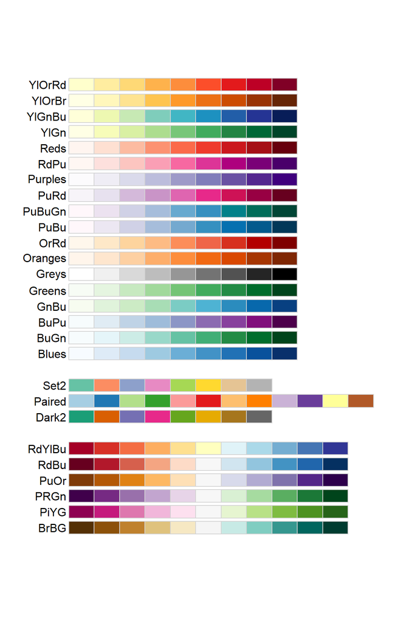

```r
display.brewer.all(colorblindFriendly=TRUE)
```

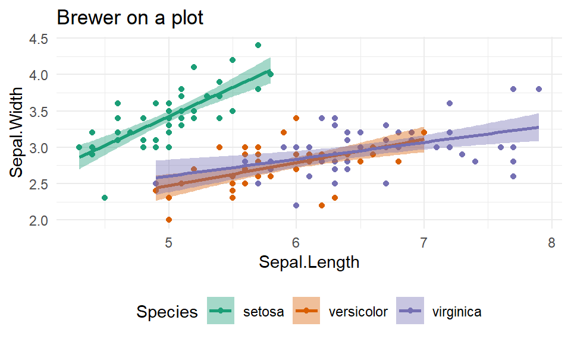

```r
ggplot(iris, aes(Sepal.Length, Sepal.Width))+
  geom_point(aes(color=Species)) +
  scale_color_brewer(palette="Dark2")+
  geom_smooth(aes(color=Species, fill=Species), formula=y ~ x, method="lm") +
  scale_fill_brewer(palette="Dark2") +
  theme_minimal() +
  theme(legend.position="bottom") +
  labs(title="Brewer on a plot")
```

Visualize a single Brewer palette by specifying its name:

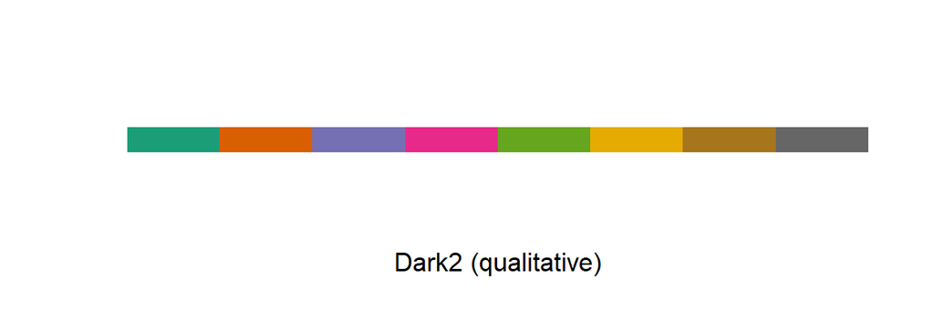

```r
display.brewer.pal(n=8, name="Dark2")
```

Get the HEX code of the palette

```r
brewer.pal(3, "Dark2")
```

```
## [1] "#1B9E77" "#D95F02" "#7570B3"
```

## 2.3 Viridis

Best for **colorblindness** and plots that need **gradient** range of colors.

```r
library("viridis")           # Load
viridis(6)
```

```
## [1] "#440154FF" "#414487FF" "#2A788EFF" "#22A884FF" "#7AD151FF" "#FDE725FF"
```

Key functions:

- `viridis(n), magma(n), inferno(n) and plasma(n)`: Generate color palettes for base plot, where n is the number of colors to return.
- `scale_color_viridis()`: Change the color of points, lines and texts
- `scale_fill_viridis()`: Change the fill color of areas (box plot, bar plot, etc)

Four options are available:

- “magma” (or “A”)
- “inferno” (or “B”)
- “plasma” (or “C”)
- “viridis” (or “D”, the default option)

```r
plt <- function(nome, opt) {
  ggplot(iris, aes(Sepal.Length, Sepal.Width))+
  geom_point(aes(color=Sepal.Length)) +
  scale_color_viridis(option=opt)+
  theme(legend.position="bottom") +
  labs(title=nome, x=element_blank(), y=element_blank())
}
```

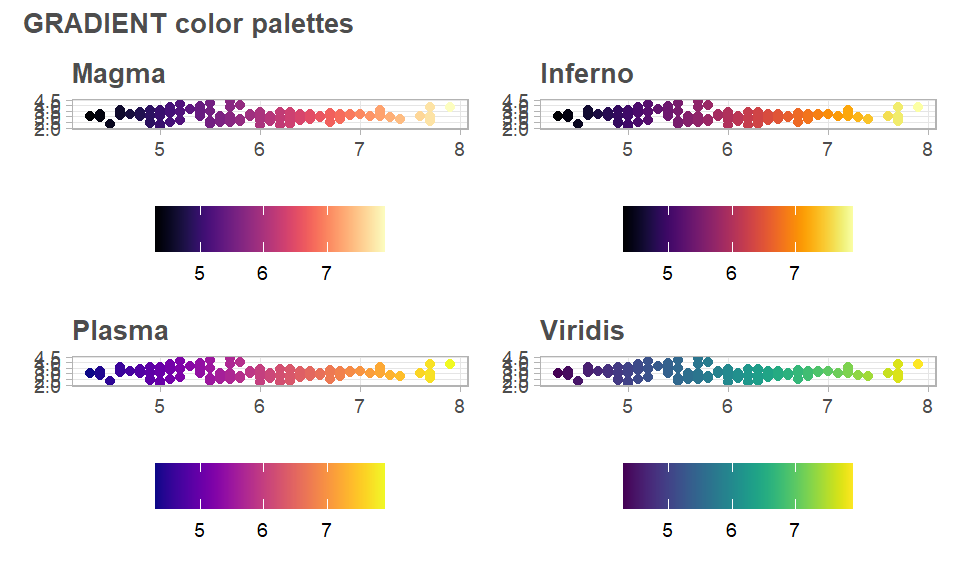

```r
plt("Magma", "A") + plt("Inferno", "B") + plt("Plasma", "C") + plt("Viridis", "D") +
  plot_annotation(title="GRADIENT color palettes")
```

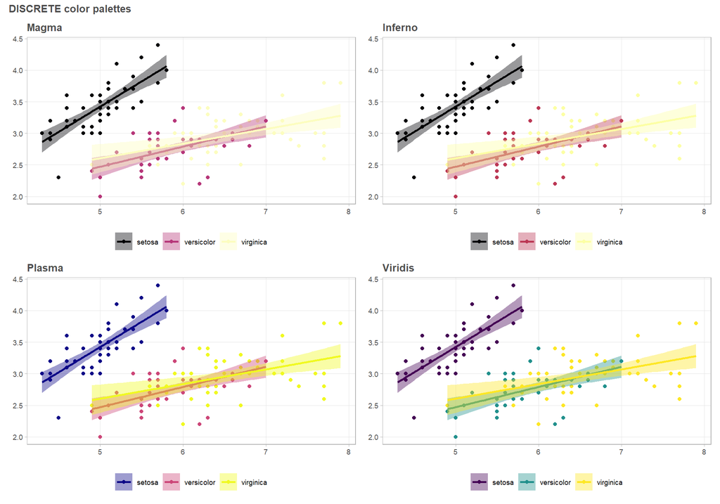

```r
plt <- function(nome, opt) {
  ggplot(iris, aes(Sepal.Length, Sepal.Width))+
  geom_point(aes(color=Species)) +
  geom_smooth(aes(color=Species, fill=Species), formula=y ~ x, method="lm") +
  scale_color_viridis(discrete=TRUE, option=opt)+
  scale_fill_viridis(discrete=TRUE, option=opt) +
  theme(legend.position="bottom") +
  labs(title=nome, x=element_blank(), y=element_blank())
}

plt("Magma", "A") + plt("Inferno", "B") + plt("Plasma", "C") + plt("Viridis", "D") +
  plot_annotation(title="DISCRETE color palettes")
```

# 3 BASIC PLOTS

## 3.1 Scatter plot

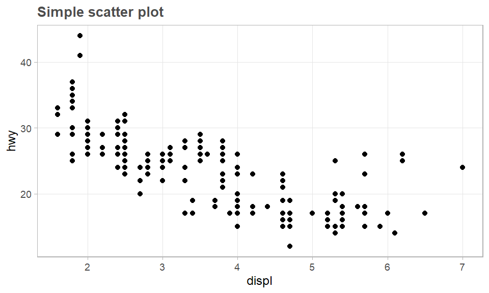

```r
ggplot(data=mpg) + # layer1 => data
  geom_point(        # layer2 => geom (points)
    mapping=aes(x=displ, y=hwy) # mapping => how variables map to visuals
  ) +
  labs(title="Simple scatter plot")
```

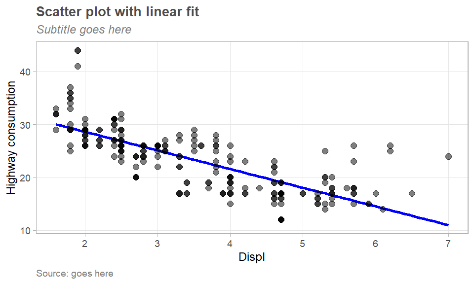

```r
mpg |>  ggplot(aes(displ, hwy)) +
  geom_smooth(method="lm", se=FALSE,            # linear fit to the data point
              color="blue", size=1) +           # tuning line color and thickness
  geom_point(alpha=0.5, size=2) +               # tuning the transparency and size of data points
  labs(x="Displ", y="Highway consumption",      # adding titles to the axis
       title="Scatter plot with linear fit",      # adding title to the plot
       subtitle="Subtitle goes here",             # adding subtitles to the plot
       caption="Source: goes here")               # adding caption to the plot
```

Sometimes the behavior of the data is more complex and in those cases, a linear fit is not an option. For these types of cases either we can use the default smoothing function or define our own function.

Below we can see three plots, one on the left uses the default `geom_smooth()` function, the middle one uses the linear fit and the rightmost uses the user-defined function.

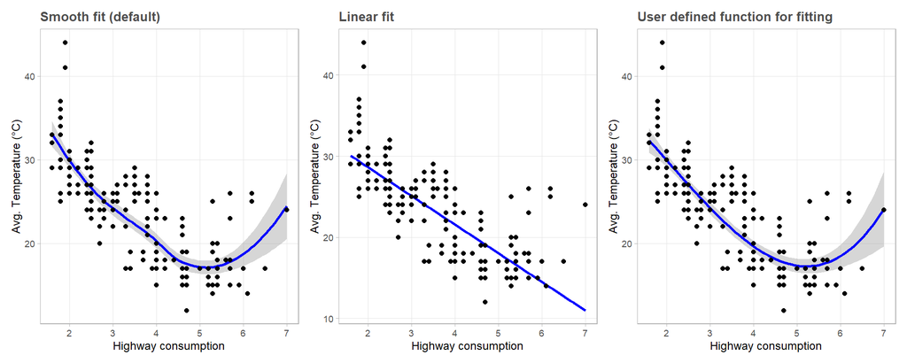

```r
### default smooth fit
p2 <- mpg |> ggplot(aes(displ, hwy)) +
  geom_smooth(stat="smooth", color="blue", size=1) +
  geom_point() +
  labs(x="Highway consumption", y="Avg. Temperature (°C)",
       title="Smooth fit (default)")

### linear fit
p3 <- mpg |> ggplot(aes(displ, hwy)) +
  geom_smooth(method="lm", se=FALSE,
              color="blue", size=1) +
  geom_point() +
  labs(x="Highway consumption", y="Avg. Temperature (°C)",
       title="Linear fit")

### user defined formula for fitting
p4 <- mpg |> ggplot(aes(displ, hwy)) +
  geom_smooth(method="lm", formula=y~x+I(x^2)+I(x^3),
              color="blue", size=1) +
  geom_point() +
  labs(x="Highway consumption", y="Avg. Temperature (°C)",
       title="User defined function for fitting")

p2 + p3 + p4
```

## 3.2 Line chart

cookbook-r

[Article 1](https://towardsdatascience.com/how-to-make-stunning-line-charts-in-r-a-complete-guide-with-ggplot2-91e5a607ea46)

```r
(data <- world_bank_pop |>
   filter(indicator %in% c("SP.POP.TOTL", "SP.URB.TOTL")) |>
   pivot_longer(3:20, names_to="year", names_transform=as.integer, values_to="pop") |>
   pivot_wider(names_from=indicator, values_from=pop, values_fill=0) |>
   mutate(Rural=SP.POP.TOTL - SP.URB.TOTL) |> select(-SP.POP.TOTL) |>
   pivot_longer(c(SP.URB.TOTL,Rural), names_to="type", values_to="pop", values_drop_na=T) |>
   mutate(type=ifelse(type=="Rural", type, "Urban")) |>
   summarise(pop=round(sum(pop)/1e9), .by=c(year, type)))
```

```
## # A tibble: 36 × 3
##     year type    pop
##    <int> <chr> <dbl>
##  1  2000 Urban    29
##  2  2000 Rural    36
##  3  2001 Urban    29
##  4  2001 Rural    37
##  5  2002 Urban    30
##  6  2002 Rural    37
##  7  2003 Urban    31
##  8  2003 Rural    37
##  9  2004 Urban    32
## 10  2004 Rural    37
## # ℹ 26 more rows
```

**Simple line chart**

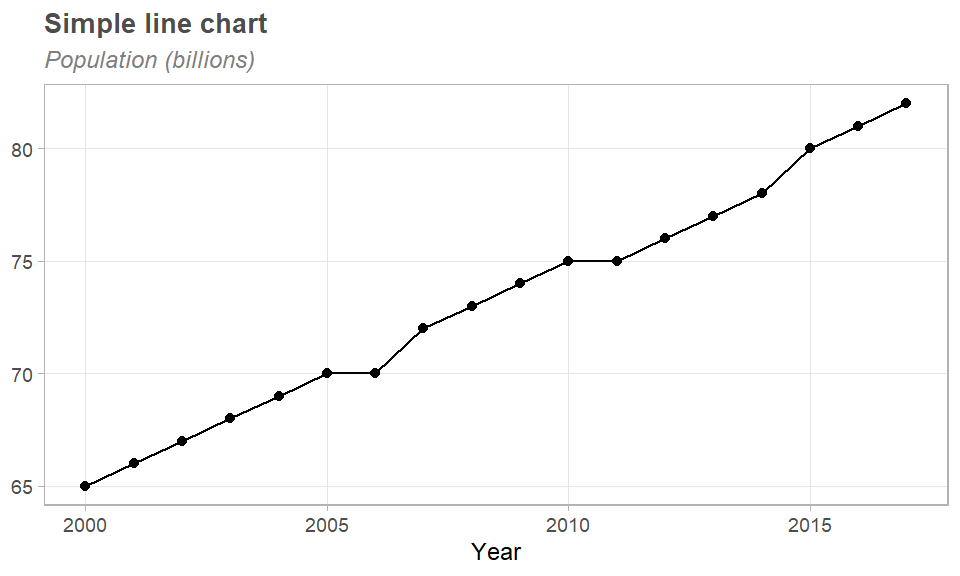

```r
data |> summarise(pop=sum(pop), .by=year) |>
  ggplot(aes(x=year, y=pop, group=1)) +
  geom_line() + geom_point() +
  scale_y_continuous(labels=scales::label_number()) +
  labs(title="Simple line chart", x="Year", y=NULL,
       subtitle="Population (billions)")
```

**Multiple lines**

PLOT Multiple lines by color Planos

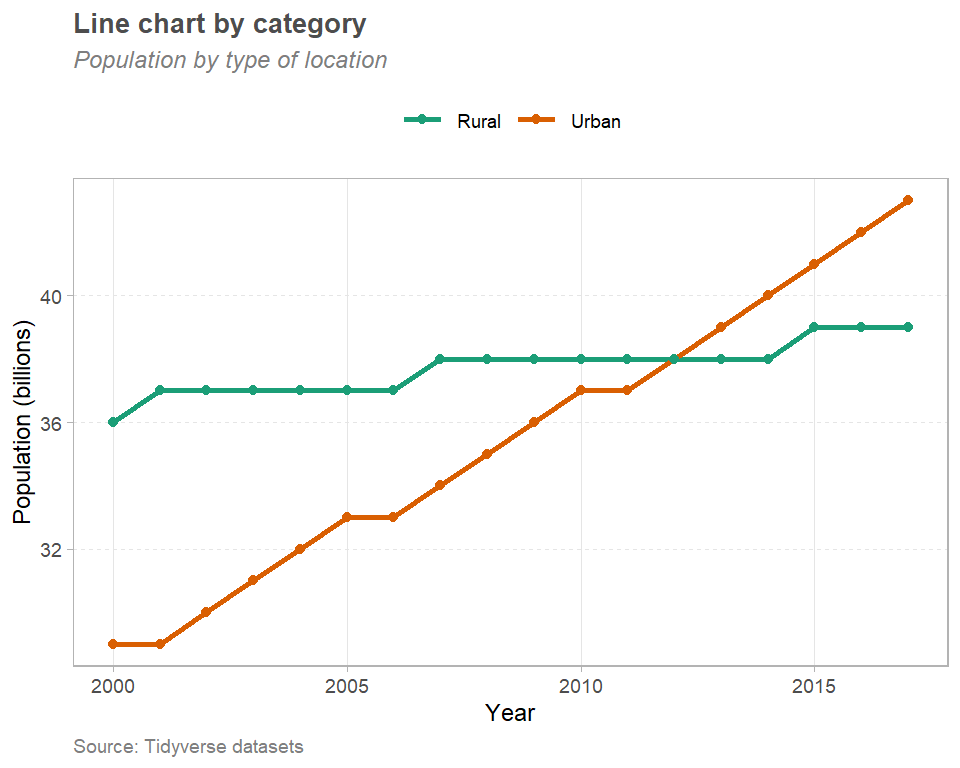

```r
data |>
  ggplot(aes(x=year, y=pop, group=type, color=type)) +
  geom_line(size=1) + geom_point() +
  scale_color_brewer(palette="Dark2") +
  # Texto: Títulos e notas
  labs(
    title="Line chart by category",
    subtitle="Population by type of location",
    caption="Source: Tidyverse datasets",
    x="Year",
    y="Population (billions)"
  ) +
  theme(
    panel.border=element_rect(fill=NA),
    panel.grid.major.y=element_line(linetype='dashed')
  )
```

*Too many lines! Need a continuous scale of gradient colors!*

I have data with about 100 ordered categories. I would like to plot each category as a line separately, with the line colors ranging from a low value (say, blue) to a high value (say, red).

Since a discrete legend is useless anyway, you could use a continuous color scale:

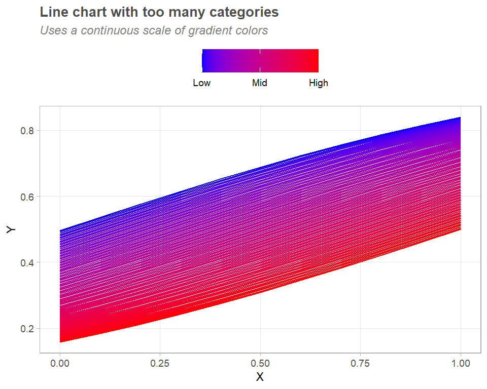

```r
df <- data.frame(expand.grid(1:100, seq(0, 1, by=.1)))
names(df) <- c("category", "X")
df <- within(df, {
  Y <- pnorm(X, mean=1:100 / 100)
  category <- factor(1:100)
  })

ggplot(data=df, aes(x=X, y=Y, color=as.integer(category), group=category)) +
  geom_line() +
  scale_colour_gradient(
    name="category", low="blue", high="red",
    # Manipulate the labels names on the legend:
    breaks=c(1,50,100), labels=c('Low','Mid','High'),
  ) +
  labs(title="Line chart with too many categories",
       subtitle="Uses a continuous scale of gradient colors")
```

## 3.3 Bar chart

cookbook-r  
[article](https://towardsdatascience.com/how-to-make-stunning-bar-charts-in-r-a-complete-guide-with-ggplot2-c8f3b87de4d1)

Note you can adjust the width of the bar. The default width between bars is 0.9. The closer the width is to 1, the closer together the bars will be. The closer the width is to 0, the more spread out the bars will be.

```r
(data <- midwest |> summarise(across(popwhite:popother, sum), .by=state) |>
  pivot_longer(popwhite:popother, values_to="pop", names_to="race") |>
  mutate(race=str_sub(race, 4,-1),
         race=if_else(race %in% c("white"), race, "other"),
         race=factor(race, levels=c("other","white"))) |>
  summarise(pop=sum(pop), .by=c(state, race)))
```

```
## # A tibble: 10 × 3
##    state race      pop
##    <chr> <fct>   <int>
##  1 IL    white 8952978
##  2 IL    other 2477624
##  3 IN    white 5020700
##  4 IN    other  523459
##  5 MI    white 7756086
##  6 MI    other 1539211
##  7 OH    white 9521756
##  8 OH    other 1325359
##  9 WI    white 4512523
## 10 WI    other  379246
```

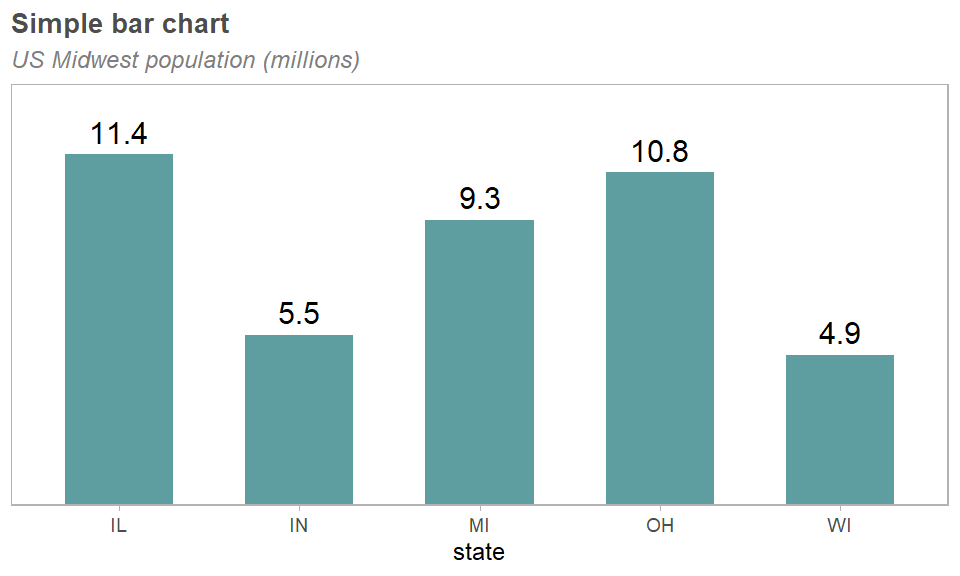

```r
data |> summarise(pop=sum(pop), .by=state) |>
  ggplot(aes(x=state, y=pop)) +
  # geom_col() == geom_bar(stat="identity") # default=stacked bars
  # geom_bar(stat='identity', fill="lightblue") +
  geom_col(
    fill="cadetblue",
    width=.6             # control the width of the columns
  ) +
  geom_text(aes(label=scales::number(pop, scale=1/1e6, accuracy=.1)),
            vjust=-0.5, size=4) +
  scale_y_continuous(expand=expansion(mult=c(0,.2)), breaks=NULL) +
  theme(panel.grid.major.x=element_blank()) +
  labs(title="Simple bar chart", y=NULL, subtitle="US Midwest population (millions)")
```

### 3.3.1 Stacked bar

[stacked](https://ggplot2.tidyverse.org/reference/position_stack.html)

The ggplot2 package uses stacked bar charts by default.

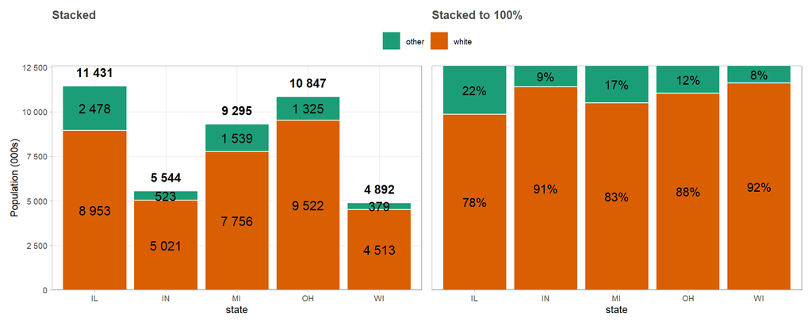

```r
p1 <- data |> mutate(pop=pop/1e3) |>
  ggplot(aes(x=state, y=pop, fill=race)) +
  geom_col(color="white") + # default position="stack"
  scale_fill_brewer(palette="Dark2") +
  # Label the groups
  geom_text(aes(label=scales::number(pop, accuracy=1)),
            position=position_stack(vjust=0.5),
            check_overlap=T,
            color="black", size=4) +
  # Label the total on top of the bars
  geom_text(aes(label=scales::number(after_stat(y), accuracy=1), group=state),
            stat="summary", fun=sum, vjust=-1,
            fontface="bold") +
  # Create a little breathing space on top of the chart:
  scale_y_continuous(expand=expansion(mult=c(0,0.1)),
                     labels=scales::label_number()) +
  labs(title="Stacked", y="Population (000s)")


p2 <- data |>
  mutate(pct=pop/sum(pop), .by=state) |>
  ggplot(aes(x=state, y=pct, fill=race)) +
  geom_col(color="white") +
  geom_text(aes(label=scales::percent(pct, accuracy=1), group=race),
            position=position_fill(.5), check_overlap=T) +
  scale_fill_brewer(palette="Dark2") +
  scale_y_continuous(breaks=NULL, expand=expansion(mult=c(0,0))) +
  labs(title="Stacked to 100%", y=NULL)

p1 + p2 + plot_layout(guides='collect')
```

Here’s a solution that adds a “position” column to the df, to use with `geom_text()` and place the labels exactly where they belong:

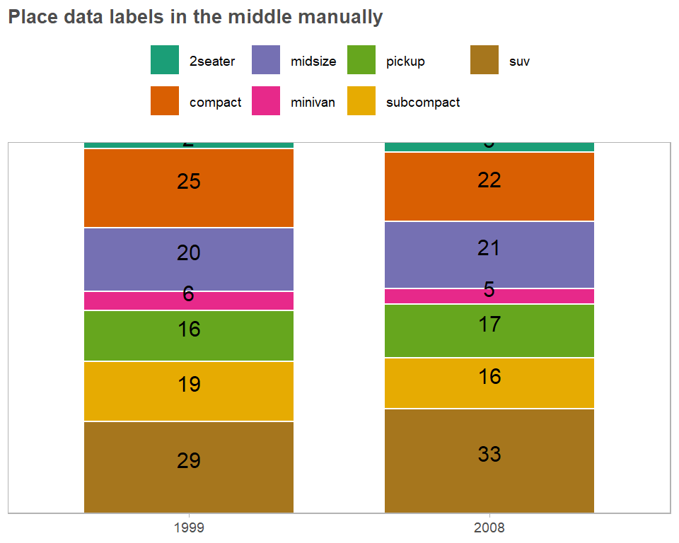

```r
mpg |> group_by(class, year=as.factor(year)) |> tally() |> ungroup() |>
  arrange(desc(class)) |>
  mutate(pos=cumsum(n) - n/2, .by=year) |> # create "position" column as 1/2 the y-axis variable
  ggplot() +
  geom_col(aes(x=year, y=n, fill=class), width=.7, color="white") +
  geom_text(aes(x=year,
                y=pos, # use "position" column
                label=prettyNum(n, big.mark=".", decimal.mark=",")),
            vjust=0, size=4, check_overlap=T) +
  scale_fill_brewer(palette="Dark2") +
  scale_y_continuous(expand=c(0,0), breaks=NULL) +
  labs(title="Place data labels in the middle manually",
       y=NULL, x=NULL)
```

### 3.3.2 Grouped bar

Adjust Spacing Between Bars: The `padding` argument of `position_dodge2()` controls the spacing between bars within the same cluster.

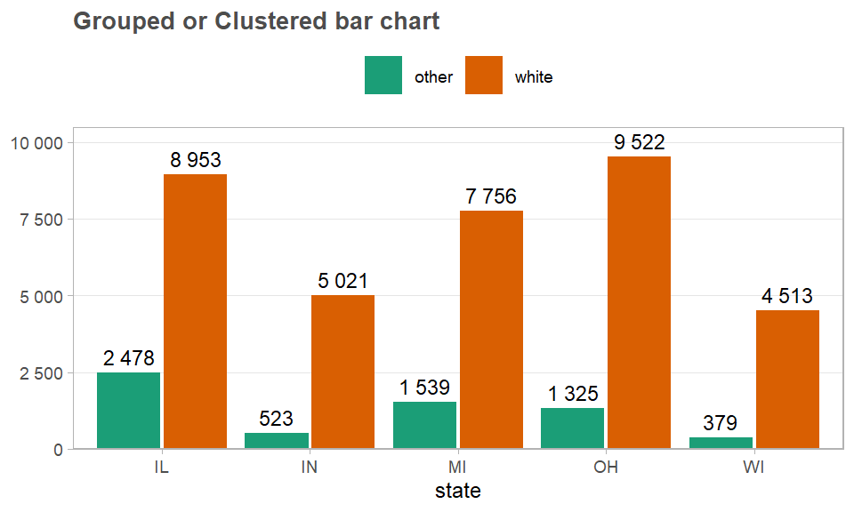

```r
data |> mutate(pop=pop/1e3) |>
  ggplot(aes(x=state, y=pop, fill=race)) +
  geom_col(position=position_dodge2(padding=.05)) +
  geom_text(aes(label=scales::number(pop, accuracy=1)),
            position=position_dodge(0.9),
            vjust=-0.5, size=3) +
  scale_y_continuous(expand=expansion(mult=c(0,.1)), labels=scales::label_number()) +
  scale_fill_brewer(palette="Dark2") +
  theme(panel.grid.major.x=element_blank(),
        legend.position="top") +
  labs(title="Grouped or Clustered bar chart", y=NULL)
```

### 3.3.3 Horizontal bar

**Horizontal bar charts** are useful when there are many categories on the x-axis or when their names are long. The `coord_flip()` is used to turn any vertical bar chart into a horizontal one:

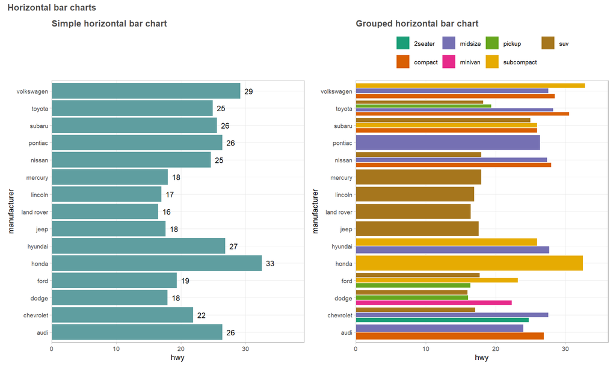

```r
p1 <- mpg |>
  summarise(hwy=mean(hwy), .by=manufacturer) |>
  ggplot(aes(x=manufacturer, y=hwy)) +
  geom_col(fill="cadetblue") +
  geom_text(aes(label=scales::number(hwy,accuracy=1)), hjust=-0.5, size=3) +
  scale_y_continuous(expand=expansion(mult=c(0,.2))) +
  labs(title="Simple horizontal bar chart") +
  coord_flip()  # <- FLIP AXES

p2 <- mpg |>
  summarise(hwy=mean(hwy), .by=c(manufacturer, class)) |>
  ggplot(aes(x=manufacturer, y=hwy,
             fill=class)) + # defines global fill to group everywhere by product
  geom_col(position=position_dodge(), color="white") +
  scale_fill_brewer(palette="Dark2") +
  scale_y_continuous(expand=expansion(mult=c(0,.1))) +
  labs(title="Grouped horizontal bar chart") +
  coord_flip()

p1 + p2 + plot_annotation(title="Horizontal bar charts")
```

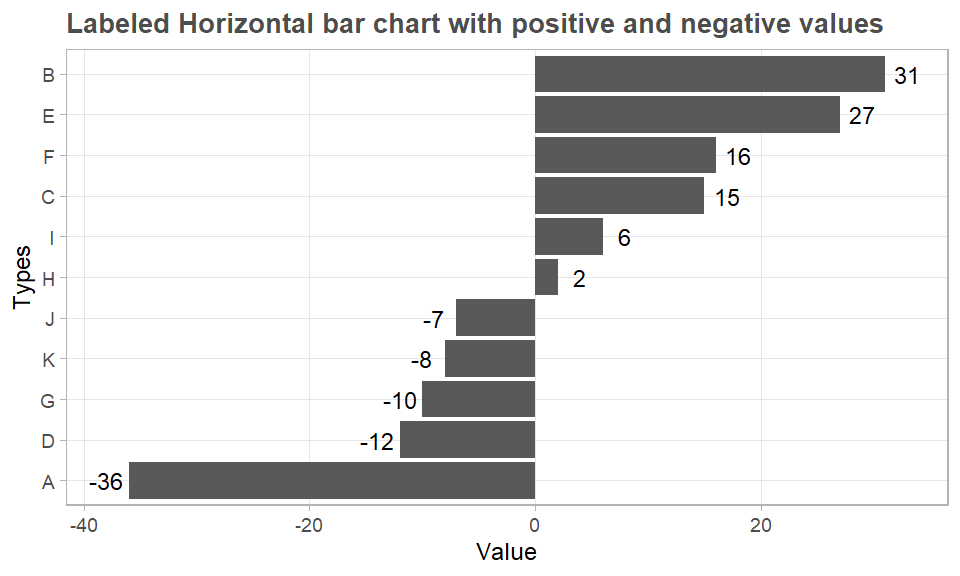

```r
data <- read.table(text = "sample Types Value
sample1 A   -36
sample2 B   31
sample1 C   15
sample2 D   -12
sample1 E   27
sample2 F  16
sample2 G  -10
sample2 H  2
sample2 I  6
sample2 J  -7
sample2 K  -8"
, header=TRUE)

data |>
  mutate(Types = fct_reorder(Types, Value)) |>
  ggplot(aes(x=Value, y=Types)) +
  geom_col() +
  # FOR DATA LABELS:
  geom_text(
    aes(
      label = Value,
      # x/y mapping determines label position
      # the sign() of a real number is +1/0/−1 if the number is positive/0/negative
      # The coefficient (2) needs to be adjusted to your data
      x = Value + 2 * sign(Value)
    ),
    size =3) +
  labs(title="Labeled Horizontal bar chart with positive and negative values")
```

Note that `sign()` returns a vector with the signs of the corresponding elements of x (the sign of a real number is 1, 0, or −1 if the number is positive, zero, or negative, respectively).

## 3.4 Area chart

Stacking is also the default behaviour for most area plots. Stacking area charts are also useful for time series.

```r
(data <- world_bank_pop |>
   filter(indicator %in% c("SP.POP.TOTL", "SP.URB.TOTL")) |>
   pivot_longer(3:20, names_to="year", names_transform=as.integer, values_to="pop") |>
   pivot_wider(names_from=indicator, values_from=pop, values_fill=0) |>
   mutate(Rural=SP.POP.TOTL - SP.URB.TOTL) |> select(-SP.POP.TOTL) |>
   pivot_longer(c(SP.URB.TOTL,Rural), names_to="type", values_to="pop", values_drop_na=T) |>
   mutate(type=ifelse(type=="Rural", type, "Urban")) |>
   summarise(pop=round(sum(pop)/1e9), .by=c(year, type)))
```

```
## # A tibble: 36 × 3
##     year type    pop
##    <int> <chr> <dbl>
##  1  2000 Urban    29
##  2  2000 Rural    36
##  3  2001 Urban    29
##  4  2001 Rural    37
##  5  2002 Urban    30
##  6  2002 Rural    37
##  7  2003 Urban    31
##  8  2003 Rural    37
##  9  2004 Urban    32
## 10  2004 Rural    37
## # ℹ 26 more rows
```

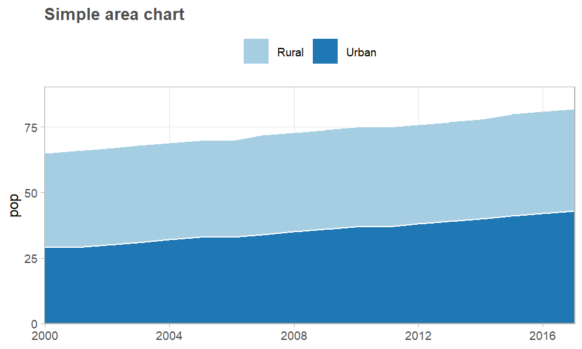

```r
data |>
  ggplot(aes(x=year, y=pop, fill=type, group=type)) +
  geom_area(color="white") +
  scale_fill_brewer(palette="Paired") +
  scale_y_continuous(expand=expansion(mult=c(0,.1))) +
  scale_x_continuous(expand=c(0,0)) +
  labs(title="Simple area chart", x=NULL)
```

## 3.5 Combo bar+line

[R Graph Gallery - Dual Y axis](https://r-graph-gallery.com/line-chart-dual-Y-axis-ggplot2.html)

Combine bar and line chart

Sometimes while dealing with hierarchical data we need to combine two or more various chart types into a single chart for better visualization and analysis.

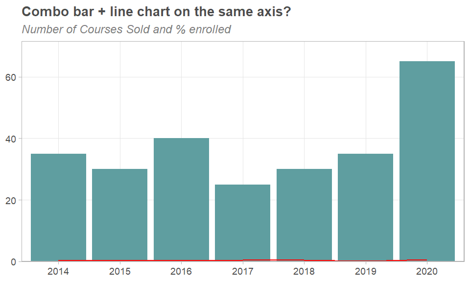

```r
data <- data.frame(
  year=c(2014, 2015, 2016, 2017, 2018, 2019,2020),
  course=c(35, 30, 40, 25, 30, 35, 65),
  pct_enroll=c(0.3, 0.25, 0.3, 0.5, 0.4, 0.2, 0.6)
)

data |> ggplot(aes(x=as.factor(year))) +
  geom_col(aes(y=course), fill="cadetblue")+
  geom_line(aes(y=pct_enroll, group=1), color="red")+
  scale_y_continuous(expand=expansion(mult=c(0,.1))) +
  labs(title= "Combo bar + line chart on the same axis?",
       x=NULL, y=NULL,
       subtitle="Number of Courses Sold and % enrolled")
```

So, we need a secondary axis in order to fit the line properly in the same chart area.

As scaling comes into the picture, we have to use the R function `scale_y_continuous( )`. Also, another function `sec_axis( )` is used to add a secondary axis and assign the specifications to it.

Syntax:

`sec_axis(trans,name,breaks,labels,guide)`

Parameters :

trans : A formula or function needed to transform.  
name : The name of the secondary axis.

Since we are dealing with a secondary Y-axis, so we need to write the command inside `scale_y_continuous( )`.

Syntax:

`scale_y_continuous(name,labels,position,sec.axis,limits,breaks)`

The scaling factor is the trickiest part to handle while dealing with a secondary axis. Since the secondary axis needs to be in percentage we have to use the scale factor of 0.01 and write the formula of conversion in the trans argument of `sec_axis()`. And since you are scaling with 0.01 in the formula, you also have to multiply the same axis with 100 in the `geom_line()` in order to make balance in scaling.

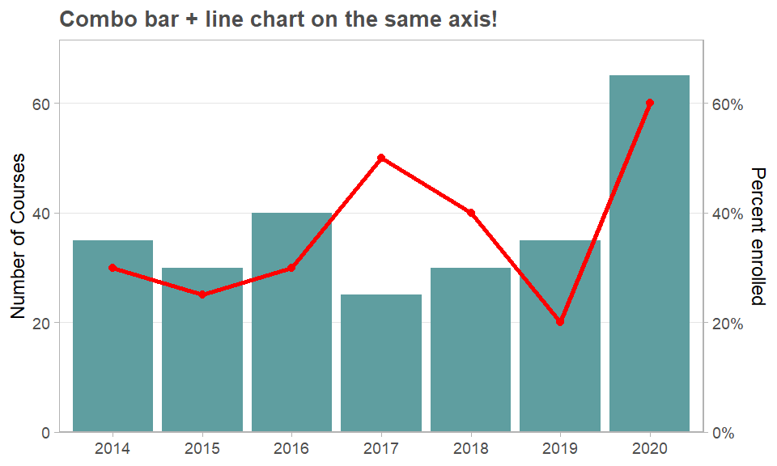

```r
data |> ggplot(aes(x=as.factor(year)))  +
  geom_col(aes(y=course), fill="cadetblue")+
  geom_line(aes(y=100*pct_enroll, group=1), color="red", size=1) +
  geom_point(aes(y=100*pct_enroll), color="red") +
  scale_y_continuous(
    expand=expansion(mult=c(0,.1)),
    sec.axis=sec_axis(~.*0.01, name="Percent enrolled", labels=scales::percent)
  ) +
  theme(panel.grid.major.x=element_blank()) +
  labs(title= "Combo bar + line chart on the same axis!",
       x=NULL, y="Number of Courses")
```

The secondary axis added is a fraction of the original axis value.

**Alternative: COWPLOT**

[Cowplot vignettes](https://wilkelab.org/cowplot/articles/index.html)

Let’s make two separate plots and then draw them on top of each other. First, let’s draw a bar plot of the number of cars in different classes in the mpg dataset.

```r
# city_mpg <- mpg |>
#   mutate(class=fct_lump(class, 4, other_level="other")) |>
#   group_by(class) |>
#   summarize(
#     mean_mpg=mean(cty),
#     count=n()
#   ) |> mutate(
#     class=fct_reorder(class, count)
#   ) |>
#   mutate(class=fct_reorder(class, -mean_mpg))
#
# p1 <- ggplot(city_mpg, aes(class, count)) +
#   geom_col(fill="#6297E770") +
#   scale_y_continuous(
#     expand=expansion(mult=c(0, 0.05)),
#     position="right"
#   ) +
#   theme_minimal_hgrid(11, rel_small=1) + # cowplot theme
#   theme(
#     panel.grid.major=element_line(color="#6297E770"),
#     axis.line.x=element_blank(),
#     axis.text.x=element_blank(),
#     axis.title.x=element_blank(),
#     axis.ticks=element_blank(),
#     axis.ticks.length=grid::unit(0, "pt"),
#     axis.text.y=element_text(color="#6297E7"),
#     axis.title.y=element_text(color="#6297E7")
#   )
#
# p2 <- ggplot(city_mpg, aes(class, mean_mpg)) +
#   geom_point(size=3, color="#D5442D") +
#   scale_y_continuous(limits=c(10, 21)) +
#   theme_half_open(11, rel_small=1) + # cowplot theme
#   theme(
#     axis.ticks.y=element_line(color="#BB2D05"),
#     axis.text.y=element_text(color="#BB2D05"),
#     axis.title.y=element_text(color="#BB2D05"),
#     axis.line.y=element_line(color="#BB2D05")
#   )
#
# # The resulting plot has dual axes. Plot alignment and plot placement are separated.
# aligned_plots <- align_plots(p1, p2, align="hv", axis="tblr")
# ggdraw(aligned_plots[[1]]) + draw_plot(aligned_plots[[2]])
```

# 4 MULTIPLE PLOTS

## 4.1 patchwork

[Assembling Plots](https://patchwork.data-imaginist.com/articles/guides/assembly.html)

[Defining Layouts](https://patchwork.data-imaginist.com/articles/guides/layout.html)

[Adding Annotation](https://patchwork.data-imaginist.com/articles/guides/annotation.html)

[Aligning across pages](https://patchwork.data-imaginist.com/articles/guides/multipage.html)

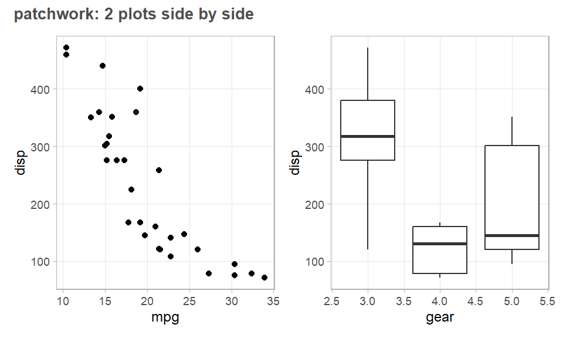

```r
theme_update(
  panel.border=element_rect(fill=NA)
)
p1 <- ggplot(mtcars) + geom_point(aes(mpg, disp))
p2 <- ggplot(mtcars) + geom_boxplot(aes(gear, disp, group=gear))

p1 + p2 + plot_annotation(title="patchwork: 2 plots side by side")
```

`patchwork` provides rich support for arbitrarily complex layouts with full alignment. As an example, check out this very readable code for nesting three plots on top of a third:

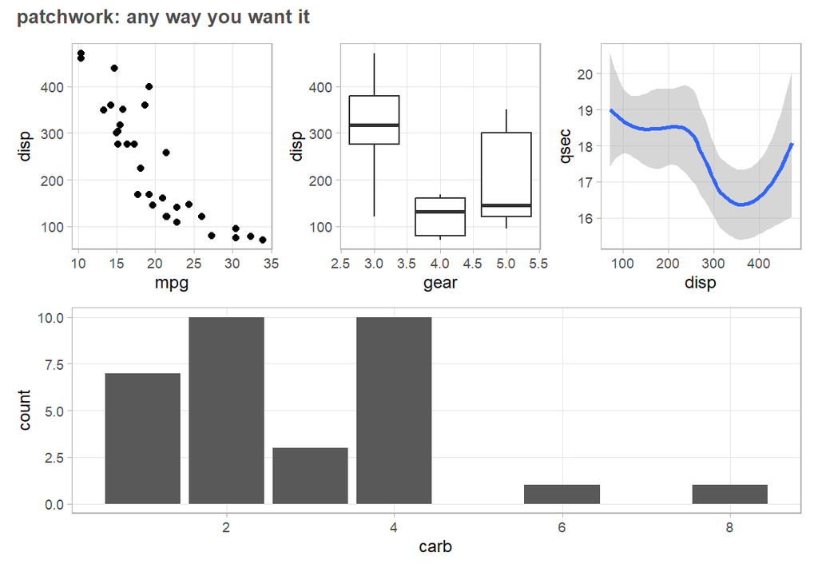

```r
p3 <- ggplot(mtcars) + geom_smooth(aes(disp, qsec))
p4 <- ggplot(mtcars) + geom_bar(aes(carb))

(p1 | p2 | p3) / p4 + plot_annotation(title="patchwork: any way you want it")
```